# Practical Machine Learning - Course Project

Sergios Koutavidis

11 July 2016

```r
knitr::opts_chunk$set(echo = TRUE)
```

## Practical Machine Learning Project : Course Project

# Background

Using devices such as Jawbone Up, Nike FuelBand, and Fitbit it is now possible to collect a large amount of data about personal activity relatively inexpensively. These type of devices are part of the quantified self movement – a group of enthusiasts who take measurements about themselves regularly to improve their health, to find patterns in their behavior, or because they are tech geeks. One thing that people regularly do is quantify how much of a particular activity they do, but they rarely quantify how well they do it. In this project, your goal will be to use data from accelerometers on the belt, forearm, arm, and dumbell of 6 participants. They were asked to perform barbell lifts correctly and incorrectly in 5 different ways. More information is available from the website here: http://groupware.les.inf.puc-rio.br/har (see the section on the Weight Lifting Exercise Dataset).

# Data

The training data for this project are available here:

https://d396qusza40orc.cloudfront.net/predmachlearn/pml-training.csv

The test data are available here:

https://d396qusza40orc.cloudfront.net/predmachlearn/pml-testing.csv

The data for this project come from this source: http://groupware.les.inf.puc-rio.br/har

# Goal

# Libraries and set up

```r
library(knitr)
library(caret)
```

```r
library(rpart)
library(rpart.plot)
library(rattle)
library(randomForest)
library(corrplot)
library(plyr)

set.seed(10000)
```

## Downloading and getting the data

```r
URL_train <- "http://d396qusza40orc.cloudfront.net/predmachlearn/pml-training.csv"
URL_test <-"http://d396qusza40orc.cloudfront.net/predmachlearn/pml-testing.csv"

Read_train <- read.csv(url(URL_train))
Read_test <- read.csv(url(URL_test))

inTrain  <- createDataPartition(Read_train$classe, p=0.7, list=FALSE)
Dataset_Traning <- Read_train[inTrain, ]
Dataset_Test  <- Read_train[-inTrain, ]
```

## Data cleansing

```r
Null <- nearZeroVar(Dataset_Traning)
Dataset_Traning <- Dataset_Traning[, -Null]
Dataset_Test  <- Dataset_Test[, -Null]

AllNull    <- sapply(Dataset_Traning, function(x) mean(is.na(x))) > 0.95
Dataset_Traning <- Dataset_Traning[,  AllNull==FALSE]
Dataset_Test <- Dataset_Test[,  AllNull==FALSE]

# Review columns 1-5 (x,user_name,raw_timestamp_part_1,raw_timestamp_part_2,cvtd_timestamp)
head(Dataset_Traning) [,  (1:5)]
```

```
##   X user_name raw_timestamp_part_1 raw_timestamp_part_2   cvtd_timestamp
## 1 1  carlitos           1323084231               788290 05/12/2011 11:23
## 3 3  carlitos           1323084231               820366 05/12/2011 11:23
## 5 5  carlitos           1323084232               196328 05/12/2011 11:23
## 7 7  carlitos           1323084232               368296 05/12/2011 11:23
## 8 8  carlitos           1323084232               440390 05/12/2011 11:23
## 9 9  carlitos           1323084232               484323 05/12/2011 11:23
```

```r
head(Dataset_Test) [,  (1:5)]
```

```
##     X user_name raw_timestamp_part_1 raw_timestamp_part_2   cvtd_timestamp
## 2   2  carlitos           1323084231               808298 05/12/2011 11:23
## 4   4  carlitos           1323084232               120339 05/12/2011 11:23
## 6   6  carlitos           1323084232               304277 05/12/2011 11:23
## 10 10  carlitos           1323084232               484434 05/12/2011 11:23
## 12 12  carlitos           1323084232               528316 05/12/2011 11:23
## 14 14  carlitos           1323084232               576390 05/12/2011 11:23
```

```r
#Remove them
Dataset_Traning <- Dataset_Traning[,  -(1:5)]
Dataset_Test <- Dataset_Test[,  -(1:5)]

#Number of dimensions (54)
 dim(Dataset_Traning)
```

```
## [1] 13737    54
```

```r
 dim(Dataset_Test)
```

```
## [1] 5885   54
```

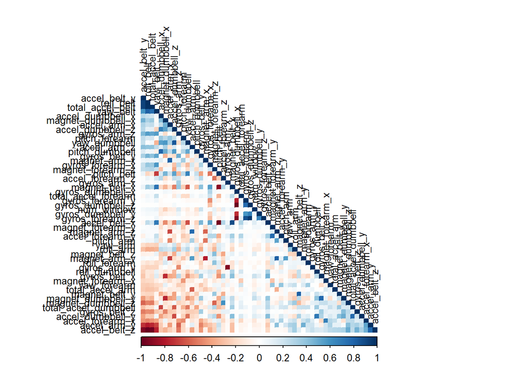

```r
correlation <- cor(Dataset_Traning[, -54])
 corrplot(correlation, order = "FPC", method = "color", type = "lower",
        tl.cex = 0.8, tl.col = rgb(0, 0, 0))
```

# Decision Tree

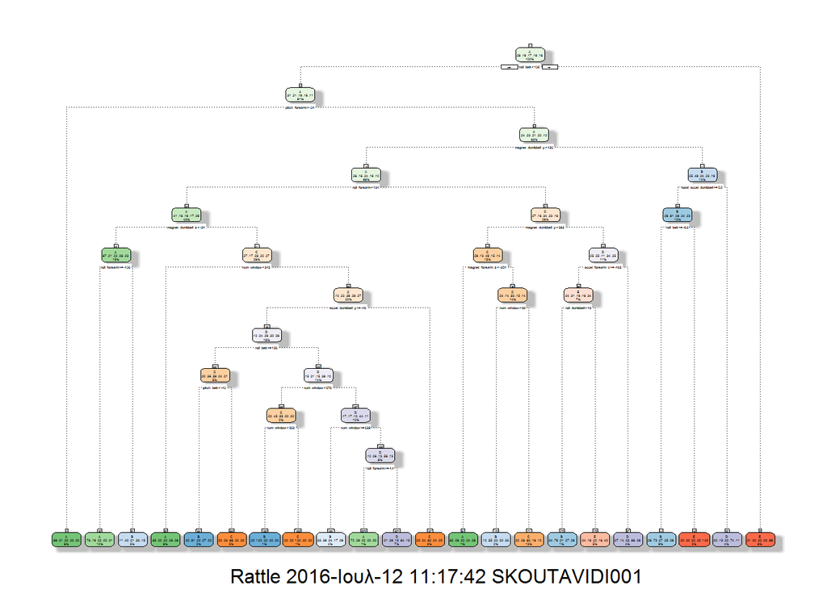

```r
#Training Set
Decision_Tree <- rpart(classe ~ ., Dataset_Traning, method="class")
fancyRpartPlot(Decision_Tree)
```

```r
#Test Set
Decision_Tree_Test <- rpart(classe ~ ., Dataset_Traning, method="class")
predictDecTree <- predict(Decision_Tree, newdata=Dataset_Test, type="class")
Confusion_matrix <- confusionMatrix(predictDecTree, Dataset_Test$classe)
Confusion_matrix
```

```
## Confusion Matrix and Statistics
##
##           Reference
## Prediction    A    B    C    D    E
##          A 1480  151   18   46   49
##          B  134  759   61  125  151
##          C   17   76  815  150   98
##          D   17   95   70  604  122
##          E   26   58   62   39  662
##
## Overall Statistics
##
##                Accuracy : 0.7341
##                  95% CI : (0.7226, 0.7453)
##     No Information Rate : 0.2845
##     P-Value [Acc > NIR] : < 2.2e-16
##
##                   Kappa : 0.6631
##  Mcnemar's Test P-Value : < 2.2e-16
##
## Statistics by Class:
##
##                      Class: A Class: B Class: C Class: D Class: E
## Sensitivity            0.8841   0.6664   0.7943   0.6266   0.6118
## Specificity            0.9373   0.9008   0.9298   0.9382   0.9615
## Pos Pred Value         0.8486   0.6171   0.7050   0.6652   0.7816
## Neg Pred Value         0.9532   0.9184   0.9554   0.9277   0.9166
## Prevalence             0.2845   0.1935   0.1743   0.1638   0.1839
## Detection Rate         0.2515   0.1290   0.1385   0.1026   0.1125
## Detection Prevalence   0.2963   0.2090   0.1964   0.1543   0.1439
## Balanced Accuracy      0.9107   0.7836   0.8621   0.7824   0.7867
```

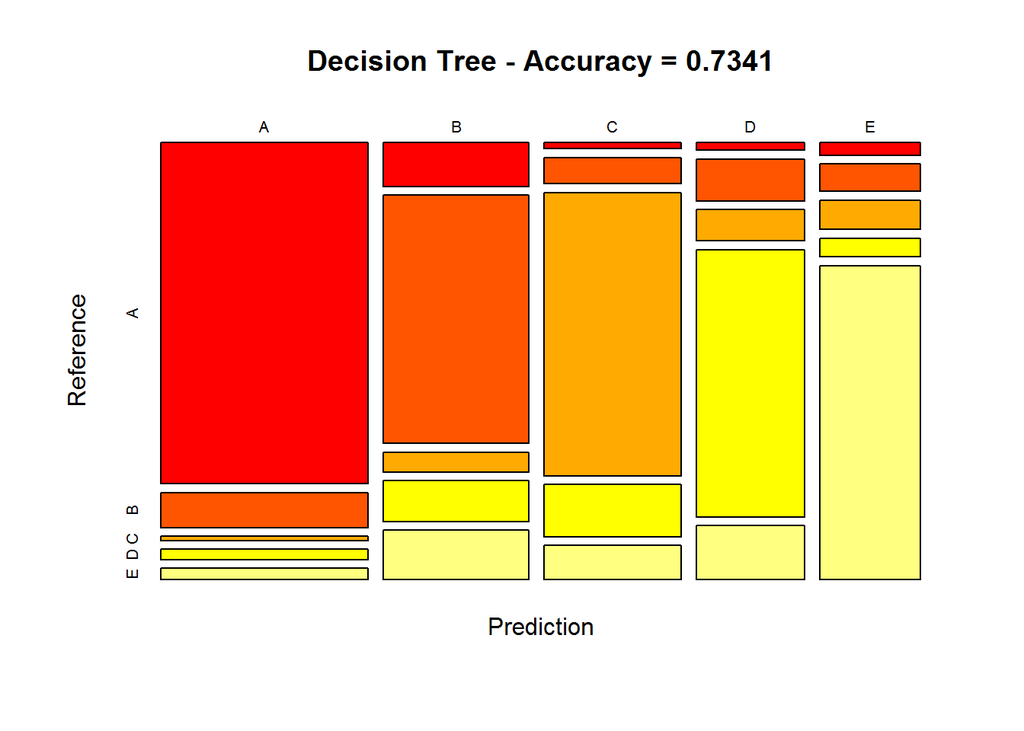

```r
plot(Confusion_matrix$table, col = heat.colors(5),
      main = paste("Decision Tree - Accuracy =",
                  round(Confusion_matrix$overall['Accuracy'], 4)))
```

# Random Forest

```r
Random_Forest_model <- trainControl(method="cv", number=3, verboseIter=FALSE)
Random_Forest_Test <- train(classe ~ ., data=Dataset_Test, method="rf",
                          trControl=Random_Forest_model)
Random_Forest_Test$finalModel
```

```
##
## Call:
##  randomForest(x = x, y = y, mtry = param$mtry)
##                Type of random forest: classification
##                      Number of trees: 500
## No. of variables tried at each split: 27
##
##         OOB estimate of  error rate: 0.87%
## Confusion matrix:
##      A    B    C   D    E  class.error
## A 1673    0    0   1    0 0.0005973716
## B   12 1122    5   0    0 0.0149253731
## C    0    8 1015   3    0 0.0107212476
## D    0    0   14 950    0 0.0145228216
## E    0    2    0   6 1074 0.0073937153
```

```r
Random_Forect_Predict <- predict(Random_Forest_Test, newdata=Dataset_Test)
Confusion_matrix_RF <- confusionMatrix(Random_Forect_Predict, Dataset_Test$classe)
Confusion_matrix_RF
```

```
## Confusion Matrix and Statistics
##
##           Reference
## Prediction    A    B    C    D    E
##          A 1674    0    0    0    0
##          B    0 1139    0    0    0
##          C    0    0 1026    0    0
##          D    0    0    0  964    0
##          E    0    0    0    0 1082
##
## Overall Statistics
##
##                Accuracy : 1
##                  95% CI : (0.9994, 1)
##     No Information Rate : 0.2845
##     P-Value [Acc > NIR] : < 2.2e-16
##
##                   Kappa : 1
##  Mcnemar's Test P-Value : NA
##
## Statistics by Class:
##
##                      Class: A Class: B Class: C Class: D Class: E
## Sensitivity            1.0000   1.0000   1.0000   1.0000   1.0000
## Specificity            1.0000   1.0000   1.0000   1.0000   1.0000
## Pos Pred Value         1.0000   1.0000   1.0000   1.0000   1.0000
## Neg Pred Value         1.0000   1.0000   1.0000   1.0000   1.0000
## Prevalence             0.2845   0.1935   0.1743   0.1638   0.1839
## Detection Rate         0.2845   0.1935   0.1743   0.1638   0.1839
## Detection Prevalence   0.2845   0.1935   0.1743   0.1638   0.1839
## Balanced Accuracy      1.0000   1.0000   1.0000   1.0000   1.0000
```

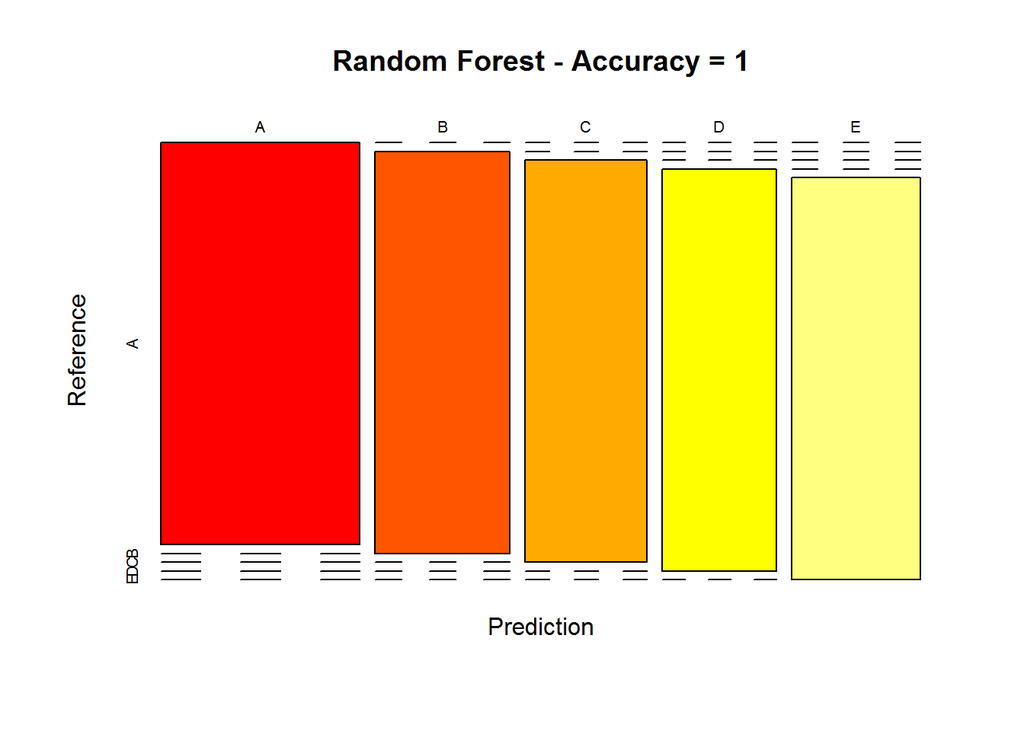

```r
plot(Confusion_matrix_RF$table, col =  heat.colors(5),
     main = paste("Random Forest - Accuracy =",
                  round(Confusion_matrix_RF$overall['Accuracy'], 4)))
```

# Generalized Boosted Model

```r
GBM_model <- trainControl(method = "repeatedcv", number = 5, repeats = 1)
GBM_Test <- train(classe ~ ., data=Dataset_Test, method = "gbm",
                    trControl = GBM_model, verbose = FALSE)
GBM_Test$finalModel
```

```
## A gradient boosted model with multinomial loss function.
## 150 iterations were performed.
## There were 53 predictors of which 43 had non-zero influence.
```

```r
GBM_Predict <- predict(GBM_Test, newdata=Dataset_Test)
Confusion_matrix_GBM <- confusionMatrix(GBM_Predict, Dataset_Test$classe)
Confusion_matrix_GBM
```

```
## Confusion Matrix and Statistics
##
##           Reference
## Prediction    A    B    C    D    E
##          A 1673    9    0    0    0
##          B    1 1127    3    1    2
##          C    0    3 1019    6    0
##          D    0    0    4  955    3
##          E    0    0    0    2 1077
##
## Overall Statistics
##
##                Accuracy : 0.9942
##                  95% CI : (0.9919, 0.996)
##     No Information Rate : 0.2845
##     P-Value [Acc > NIR] : < 2.2e-16
##
##                   Kappa : 0.9927
##  Mcnemar's Test P-Value : NA
##
## Statistics by Class:
##
##                      Class: A Class: B Class: C Class: D Class: E
## Sensitivity            0.9994   0.9895   0.9932   0.9907   0.9954
## Specificity            0.9979   0.9985   0.9981   0.9986   0.9996
## Pos Pred Value         0.9946   0.9938   0.9912   0.9927   0.9981
## Neg Pred Value         0.9998   0.9975   0.9986   0.9982   0.9990
## Prevalence             0.2845   0.1935   0.1743   0.1638   0.1839
## Detection Rate         0.2843   0.1915   0.1732   0.1623   0.1830
## Detection Prevalence   0.2858   0.1927   0.1747   0.1635   0.1833
## Balanced Accuracy      0.9986   0.9940   0.9957   0.9946   0.9975
```

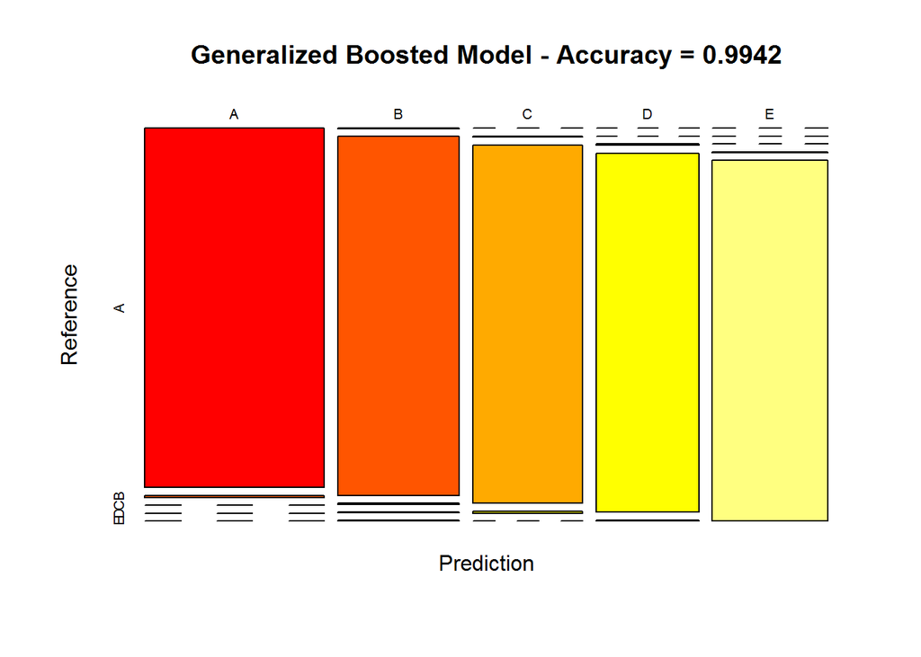

```r
plot(Confusion_matrix_GBM$table, col =  heat.colors(5),
     main = paste("Generalized Boosted Model - Accuracy =",
                  round(Confusion_matrix_GBM$overall['Accuracy'], 4)))
```

# Verdict

Following the results of the above regression models :

Random Forest Model will be selected to be applied to predict these quiz results as shown below

```r
predict <- predict(Random_Forest_Test, newdata=Read_test)
predict
```

```
##  [1] B A B A A E D B A A B C B A E E A B B B
## Levels: A B C D E
```